# Complex Networks 2

Walter Quattrociocchi

- **Data Frames**
- **Graphs From File**
- **Bipartite Networks**

### Data Frames

- The data frame is a special kind of list used for storing dataset tables.
- Think of rows as cases, columns as variables. Each column is a vector or factor.

```r
dfr1 <- data.frame( ID=1:4,
                    FirstName=c("John","Jim","Jane","Jill"),
                    Female=c(F,F,T,T),
                    Age=c(22,33,44,55) )
dfr1$FirstName
```

```
[1] John Jim  Jane Jill
Levels: Jane Jill Jim John
```

- Notice that R thinks this is a categorical variable and so it's treating it like a factor, not a character vector. To get rid of that:

```r
dfr1$FirstName <- as.vector(dfr1$FirstName)
```

### Data Frames

- Alternatively, you can tell R you don't like factors from the start using stringsAsFactors=FALSE

```r
dfr2 <- data.frame(FirstName=c("John","Jim","Jane","Jill"), stringsAsFactors=FALSE)
dfr2$FirstName   # Success: not a factor.
```

```
[1] "John" "Jim"  "Jane" "Jill"
```

### Data Frames

- Find the names of everyone over the age of 30 in the data

```r
dfr1[dfr1$Age>30,2]
```

```
[1] "Jim"  "Jane" "Jill"
```

### Data Frames

- Find the average age of all females in the data:

```r
mean ( dfr1[dfr1$Female==TRUE,4] )
```

```
[1] 49.5
```

### Zachary Karate Club

- Zachary's karate club is a social network of a university karate club, described in the paper “An Information Flow Model for Conflict and Fission in Small Groups” by Wayne W. Zachary.
- This social networkwas studied by Wayne W. Zachary for a period of three years from 1970 to 1972.[2] The network captures 34 members of a karate club, documenting links between pairs of members who interacted outside the club. During the study a conflict arose between the administrator “John A” and instructor “Mr. Hi” (pseudonyms), which led to the split of the club into two. Half of the members formed a new club around Mr. Hi; members from the other part found a new instructor or gave up karate. Based on collected data Zachary correctly assigned all but one member of the club to the groups they actually joined after the split.

### Igraph and Zachary Karate Club

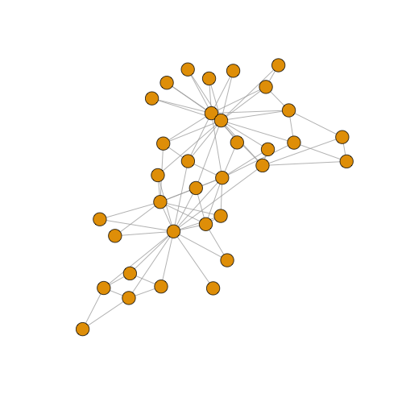

```r
library(igraph)
zach <- graph("Zachary") # the Zachary carate club
plot(zach, vertex.size=10, vertex.label=NA)
```

- Exercise: Characterize this Network

### Reading network data from files: edge list

```r
library(igraph)
rm(list = ls()) # clear the workspace
```

- reading edge list (i -> j)

```r
nodes <- read.csv("Dataset1-Media-Example-NODES.csv", header=T, as.is=T)
links <- read.csv("Dataset1-Media-Example-EDGES.csv", header=T, as.is=T)
```

### Examine the data

```r
head(nodes)
```

```
   id               media media.type type.label audience.size
1 s01            NY Times          1  Newspaper            20
2 s02     Washington Post          1  Newspaper            25
3 s03 Wall Street Journal          1  Newspaper            30
4 s04           USA Today          1  Newspaper            32
5 s05            LA Times          1  Newspaper            20
6 s06       New York Post          1  Newspaper            50
```

```r
head(links)
```

```
  from  to weight      type
1  s01 s02     10 hyperlink
2  s01 s02     12 hyperlink
3  s01 s03     22 hyperlink
4  s01 s04     21 hyperlink
5  s04 s11     22   mention
6  s05 s15     21   mention
```

```r
nrow(nodes);# OR length(unique(nodes$id))
```

```
[1] 17
```

```r
nrow(links);# OR nrow(unique(links[,c("from", "to")]))
```

```
[1] 52
```

### Weighted Networks

- Collapse multiple links of the same type between the same two nodes by summing their weights, using aggregate() by “from”, “to”, & “type”: (we don't use “simplify()” here so as not to collapse different link types)

```r
links <- aggregate(links[,3], links[,-3], sum)
links <- links[order(links$from, links$to),]
colnames(links)[4] <- "weight"
rownames(links) <- NULL
```

### Reading network data from files: matrix

```r
#Reading data
nodes2 <- read.csv("Dataset2-Media-User-Example-NODES.csv", header=T, as.is=T)
links2 <- read.csv("Dataset2-Media-User-Example-EDGES.csv", header=T, row.names=1)
# Examine the data:
head(nodes2)
```

```
   id   media media.type media.name audience.size
1 s01     NYT          1  Newspaper            20
2 s02    WaPo          1  Newspaper            25
3 s03     WSJ          1  Newspaper            30
4 s04    USAT          1  Newspaper            32
5 s05 LATimes          1  Newspaper            20
6 s06     CNN          2         TV            56
```

```r
head(links2)
```

```
    U01 U02 U03 U04 U05 U06 U07 U08 U09 U10 U11 U12 U13 U14 U15 U16 U17
s01   1   1   1   0   0   0   0   0   0   0   0   0   0   0   0   0   0
s02   0   0   0   1   1   0   0   0   0   0   0   0   0   0   0   0   0
s03   0   0   0   0   0   1   1   1   1   0   0   0   0   0   0   0   0
s04   0   0   0   0   0   0   0   0   1   1   1   0   0   0   0   0   0
s05   0   0   0   0   0   0   0   0   0   0   1   1   1   0   0   0   0
s06   0   0   0   0   0   0   0   0   0   0   0   0   1   1   0   0   1
    U18 U19 U20
s01   0   0   0
s02   0   0   1
s03   0   0   0
s04   0   0   0
s05   0   0   0
s06   0   0   0
```

### Bipartite: adjacency matrix for a two-mode network

```r
links2 <- as.matrix(links2)
dim(links2)
```

```
[1] 10 20
```

```r
dim(nodes2)
```

```
[1] 30  5
```

### Turning networks into igraph objects

- Converting the data to an igraph object:
- The graph.data.frame function, which takes two data frames: 'd' and 'vertices'.
  - 'd' describes the edges of the network - it should start with two columns containing the source and target node IDs for each network tie.
  - 'vertices' should start with a column of node IDs.
- Any additional columns in either data frame are interpreted as attributes.

### Turning networks into igraph objects

```r
net <- graph_from_data_frame(d=links, vertices=nodes, directed=T)

class(net)
```

```
[1] "igraph"
```

```r
net
```

```
IGRAPH ee8ad99 DNW- 17 49 --
+ attr: name (v/c), media (v/c), media.type (v/n), type.label
| (v/c), audience.size (v/n), type (e/c), weight (e/n)
+ edges from ee8ad99 (vertex names):
 [1] s01->s02 s01->s03 s01->s04 s01->s15 s02->s01 s02->s03 s02->s09
 [8] s02->s10 s03->s01 s03->s04 s03->s05 s03->s08 s03->s10 s03->s11
[15] s03->s12 s04->s03 s04->s06 s04->s11 s04->s12 s04->s17 s05->s01
[22] s05->s02 s05->s09 s05->s15 s06->s06 s06->s16 s06->s17 s07->s03
[29] s07->s08 s07->s10 s07->s14 s08->s03 s08->s07 s08->s09 s09->s10
[36] s10->s03 s12->s06 s12->s13 s12->s14 s13->s12 s13->s17 s14->s11
[43] s14->s13 s15->s01 s15->s04 s15->s06 s16->s06 s16->s17 s17->s04
```

### Turning networks into igraph objects

- Edges and Vertices

```r
E(net)
```

```
+ 49/49 edges from ee8ad99 (vertex names):
 [1] s01->s02 s01->s03 s01->s04 s01->s15 s02->s01 s02->s03 s02->s09
 [8] s02->s10 s03->s01 s03->s04 s03->s05 s03->s08 s03->s10 s03->s11
[15] s03->s12 s04->s03 s04->s06 s04->s11 s04->s12 s04->s17 s05->s01
[22] s05->s02 s05->s09 s05->s15 s06->s06 s06->s16 s06->s17 s07->s03
[29] s07->s08 s07->s10 s07->s14 s08->s03 s08->s07 s08->s09 s09->s10
[36] s10->s03 s12->s06 s12->s13 s12->s14 s13->s12 s13->s17 s14->s11
[43] s14->s13 s15->s01 s15->s04 s15->s06 s16->s06 s16->s17 s17->s04
```

```r
V(net)
```

```
+ 17/17 vertices, named, from ee8ad99:
 [1] s01 s02 s03 s04 s05 s06 s07 s08 s09 s10 s11 s12 s13 s14 s15 s16 s17
```

### Turning networks into igraph objects

- Edges and Vertices Attributes

```r
E(net)$type
```

```
 [1] "hyperlink" "hyperlink" "hyperlink" "mention"   "hyperlink"
 [6] "hyperlink" "hyperlink" "hyperlink" "hyperlink" "hyperlink"
[11] "hyperlink" "hyperlink" "mention"   "hyperlink" "hyperlink"
[16] "hyperlink" "mention"   "mention"   "hyperlink" "mention"
[21] "mention"   "hyperlink" "hyperlink" "mention"   "hyperlink"
[26] "hyperlink" "mention"   "mention"   "mention"   "hyperlink"
[31] "mention"   "hyperlink" "mention"   "mention"   "mention"
[36] "hyperlink" "mention"   "hyperlink" "mention"   "hyperlink"
[41] "mention"   "mention"   "mention"   "hyperlink" "hyperlink"
[46] "hyperlink" "hyperlink" "mention"   "hyperlink"
```

```r
V(net)$media
```

```
 [1] "NY Times"            "Washington Post"     "Wall Street Journal"
 [4] "USA Today"           "LA Times"            "New York Post"
 [7] "CNN"                 "MSNBC"               "FOX News"
[10] "ABC"                 "BBC"                 "Yahoo News"
[13] "Google News"         "Reuters.com"         "NYTimes.com"
[16] "WashingtonPost.com"  "AOL.com"
```

### Turning networks into igraph objects

- Plotting the network

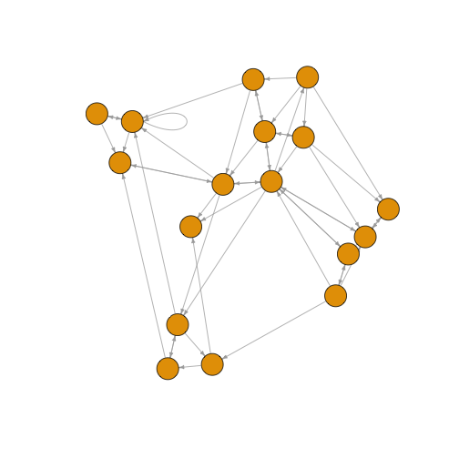

```r
plot(net, edge.arrow.size=.4,vertex.label=NA)
```

### Turning networks into igraph objects

```r
# Removing loops from the graph:
net <- simplify(net, remove.multiple = F, remove.loops = T)

# If you need them, you can extract an edge list
as_edgelist(net, names=T)
```

```
      [,1]  [,2]
 [1,] "s01" "s02"
 [2,] "s01" "s03"
 [3,] "s01" "s04"
 [4,] "s01" "s15"
 [5,] "s02" "s01"
 [6,] "s02" "s03"
 [7,] "s02" "s09"
 [8,] "s02" "s10"
 [9,] "s03" "s01"
[10,] "s03" "s04"
[11,] "s03" "s05"
[12,] "s03" "s08"
[13,] "s03" "s10"
[14,] "s03" "s11"
```

[output cut: 34 more lines]

### Turning networks into igraph objects

```r
#or a matrix from igraph networks.
as_adjacency_matrix(net, attr="weight")
```

```
17 x 17 sparse Matrix of class "dgCMatrix"

s01  . 22 22 21 .  .  .  .  .  .  .  .  .  . 20  .  .
s02 23  . 21  . .  .  .  .  1  5  .  .  .  .  .  .  .
s03 21  .  . 22 1  .  .  4  .  2  1  1  .  .  .  .  .
s04  .  . 23  . .  1  .  .  .  . 22  3  .  .  .  .  2
s05  1 21  .  . .  .  .  .  2  .  .  .  .  . 21  .  .
s06  .  .  .  . .  .  .  .  .  .  .  .  .  .  . 21 21
s07  .  .  1  . .  .  . 22  . 21  .  .  .  4  .  .  .
s08  .  .  2  . .  . 21  . 23  .  .  .  .  .  .  .  .
s09  .  .  .  . .  .  .  .  . 21  .  .  .  .  .  .  .
s10  .  .  2  . .  .  .  .  .  .  .  .  .  .  .  .  .
s11  .  .  .  . .  .  .  .  .  .  .  .  .  .  .  .  .
s12  .  .  .  . .  2  .  .  .  .  .  . 22 22  .  .  .
s13  .  .  .  . .  .  .  .  .  .  . 21  .  .  .  .  1
s14  .  .  .  . .  .  .  .  .  .  1  . 21  .  .  .  .
s15 22  .  .  1 .  4  .  .  .  .  .  .  .  .  .  .  .
s16  .  .  .  . . 23  .  .  .  .  .  .  .  .  .  . 21
s17  .  .  .  4 .  .  .  .  .  .  .  .  .  .  .  .  .
```

### Turning networks into igraph objects

```r
# Or data frames describing nodes and edges:
as_data_frame(net, what="edges")
```

```
   from  to      type weight
1   s01 s02 hyperlink     22
2   s01 s03 hyperlink     22
3   s01 s04 hyperlink     21
4   s01 s15   mention     20
5   s02 s01 hyperlink     23
6   s02 s03 hyperlink     21
7   s02 s09 hyperlink      1
8   s02 s10 hyperlink      5
9   s03 s01 hyperlink     21
10  s03 s04 hyperlink     22
11  s03 s05 hyperlink      1
12  s03 s08 hyperlink      4
13  s03 s10   mention      2
14  s03 s11 hyperlink      1
```

[output cut: 34 more lines]

```r
as_data_frame(net, what="vertices")
```

```
    name               media media.type type.label audience.size
s01  s01            NY Times          1  Newspaper            20
s02  s02     Washington Post          1  Newspaper            25
s03  s03 Wall Street Journal          1  Newspaper            30
s04  s04           USA Today          1  Newspaper            32
s05  s05            LA Times          1  Newspaper            20
s06  s06       New York Post          1  Newspaper            50
s07  s07                 CNN          2         TV            56
s08  s08               MSNBC          2         TV            34
s09  s09            FOX News          2         TV            60
s10  s10                 ABC          2         TV            23
s11  s11                 BBC          2         TV            34
s12  s12          Yahoo News          3     Online            33
s13  s13         Google News          3     Online            23
s14  s14         Reuters.com          3     Online            12
s15  s15         NYTimes.com          3     Online            24
s16  s16  WashingtonPost.com          3     Online            28
s17  s17             AOL.com          3     Online            33
```

### Turning networks into igraph objects

- Degree Distribution

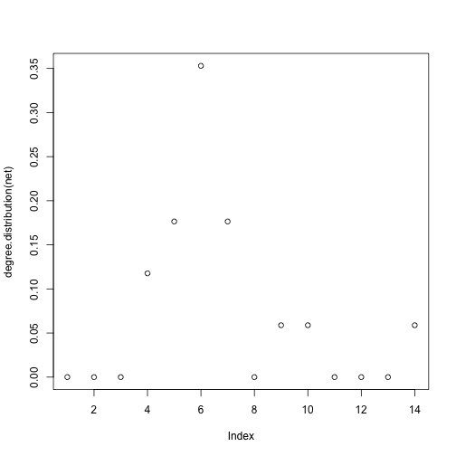

```r
library(igraph)
plot(degree.distribution(net))
```

### Turning networks into igraph objects

- The second dataset

```r
head(nodes2)
```

```
   id   media media.type media.name audience.size
1 s01     NYT          1  Newspaper            20
2 s02    WaPo          1  Newspaper            25
3 s03     WSJ          1  Newspaper            30
4 s04    USAT          1  Newspaper            32
5 s05 LATimes          1  Newspaper            20
6 s06     CNN          2         TV            56
```

```r
head(links2)
```

```
    U01 U02 U03 U04 U05 U06 U07 U08 U09 U10 U11 U12 U13 U14 U15 U16 U17
s01   1   1   1   0   0   0   0   0   0   0   0   0   0   0   0   0   0
s02   0   0   0   1   1   0   0   0   0   0   0   0   0   0   0   0   0
s03   0   0   0   0   0   1   1   1   1   0   0   0   0   0   0   0   0
s04   0   0   0   0   0   0   0   0   1   1   1   0   0   0   0   0   0
s05   0   0   0   0   0   0   0   0   0   0   1   1   1   0   0   0   0
s06   0   0   0   0   0   0   0   0   0   0   0   0   1   1   0   0   1
    U18 U19 U20
s01   0   0   0
s02   0   0   1
s03   0   0   0
s04   0   0   0
s05   0   0   0
s06   0   0   0
```

```r
net2 <- graph_from_incidence_matrix(links2)
```

### Bipartite Networks

- A built-in vertex attribute 'type' shows which mode vertices belong to.

```r
table(V(net2)$type)
```

```
FALSE  TRUE
   10    20
```

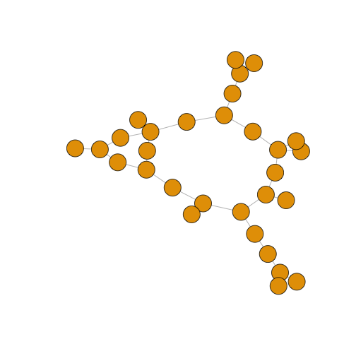

```r
plot(net2,vertex.label=NA)
```

### Bipartite Networks

- To transform a one-mode network matrix into an igraph object, use graph_from_adjacency_matrix()
- We can also easily generate bipartite projections for the two-mode network:
  - co-memberships are easy to calculate by multiplying the network matrix by its transposed matrix, or using igraph's bipartite.projection function

```r
net2.bp <- bipartite.projection(net2)
```

### Bipartite Networks

- We can calculate the projections manually as well:
  - as_incidence_matrix(net2) %*% t(as_incidence_matrix(net2))

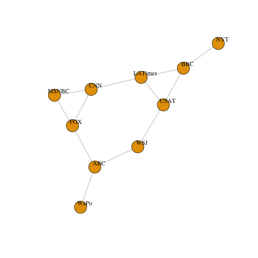

```r
plot(net2.bp$proj1, vertex.label.color="black", vertex.label.dist=1,
     vertex.label=nodes2$media[!is.na(nodes2$media.type)])
```

### Bipartite Networks

- We can calculate the projections manually as well:
  - t(as_incidence_matrix(net2)) %*% as_incidence_matrix(net2)

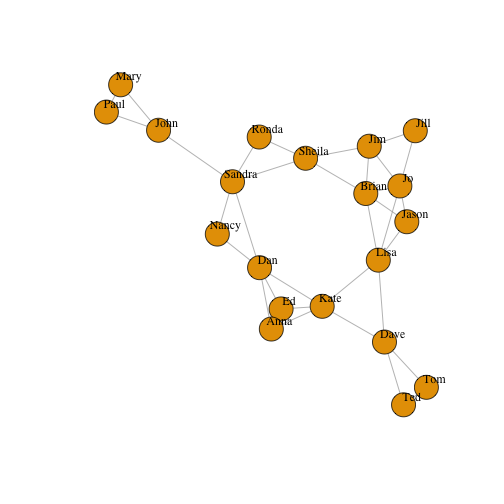

```r
plot(net2.bp$proj2, vertex.label.color="black", vertex.label.dist=1,
     vertex.label=nodes2$media[ is.na(nodes2$media.type)])
```